# Diseño 1: Muestreo Bernoulli (BE)

## Carga de Datos y Configuración Inicial

En esta sección se inicializan los datos del departamento de Paysandú, se cargan las librerías requeridas y se calculan los parámetros poblacionales fijos para el Diseño de Bernoulli.

```r
library(tidyverse)

load("Paysandú.RData")
pdu <- pay

pdu$y <- ifelse(pdu$PERAL08 == 1, 1, 0)
t <- sum(pdu$y)
N <- nrow(pdu)
n <- 600
R <- 2000

# Probabilidad de inclusión de primer orden fija
pi <- n / N
```

## Simulación (Distribución Empírica)

Se ejecutan las $R = 2000$ réplicas para evaluar de forma simultánea el estimador clásico de Horvitz-Thompson y el estimador alternativo corregido por el tamaño de muestra efectivo.

```r
set.seed(123)

simulaciones_be <- map_dfr(1:R, ~{
  epsilon <- runif(nrow(pdu))
  muestra_sim <- pdu[epsilon < pi, ]

  # 1. Estimador clásico HT
  total_sim_ht <- sum(muestra_sim$y) / pi

  # 2. Estimador alternativo corregido por el tamaño muestral observado
  total_sim_alt <- N * (sum(muestra_sim$y) / nrow(muestra_sim))

  tibble(totales_be = total_sim_ht, totales_be_alt = total_sim_alt)
})
```

## Análisis de Eficiencia (Deff)

Para evaluar el Efecto de Diseño ($Deff$) en un muestreo de Bernoulli, la teoría exige comparar su varianza frente a la de un Muestreo Aleatorio Simple ($SI$) que comparta el mismo tamaño de muestra. En este análisis, importamos la varianza empírica del diseño $SI$ con $n = 600$ fijos generada en el primer módulo, asumiendo la igualdad con respecto al tamaño de muestra esperado de Bernoulli ($E(n_s) = 600$).

Evaluamos tanto el impacto del estimador clásico (HT) como la ganancia en eficiencia obtenida al corregir por el tamaño de muestra observado mediante el estimador alternativo.

```r
# Cargamos los resultados de la simulación del Muestreo Simple
load("sim_si.RData")

var_mas     <- var(totales_si)
var_be_clásico <- var(simulaciones_be$totales_be)
var_be_alt  <- var(simulaciones_be$totales_be_alt)

deff_clásico <- var_be_clásico / var_mas
deff_alt     <- var_be_alt / var_mas

cat("Varianza MAS:", var_mas, "\n")
```

```
## Varianza MAS: 1407003
```

```r
cat("Varianza Bernoulli Clásico:", var_be_clásico, "\n")
```

```
## Varianza Bernoulli Clásico: 1903029
```

```r
cat("Varianza Bernoulli Alternativo:", var_be_alt, "\n\n")
```

```
## Varianza Bernoulli Alternativo: 1455897
```

```r
cat("Deff - Estimador Clásico:", deff_clásico, "\n")
```

```
## Deff - Estimador Clásico: 1.352541
```

```r
cat("Deff - Estimador Alternativo:", deff_alt, "\n")
```

```
## Deff - Estimador Alternativo: 1.03475
```

## Visualización y Comparación de Diseños

A continuación, se presenta la comparación gráfica de las densidades empíricas. Se superponen la curva del Muestreo Simple de control (importada), la del estimador clásico de Bernoulli (cuya mayor dispersión refleja la aleatoriedad del tamaño muestral $n_s$) y la del estimador alternativo, evidenciando visualmente cómo la corrección por tamaño de muestra estabiliza la estimación.

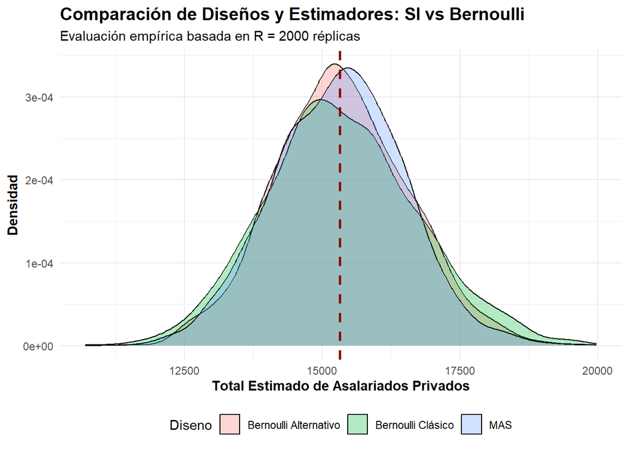

```r
resultados_grafico <- data.frame(
  Diseno = rep(c("MAS", "Bernoulli Clásico", "Bernoulli Alternativo"), each = R),
  Estimacion = c(totales_si, simulaciones_be$totales_be, simulaciones_be$totales_be_alt)
)

ggplot(resultados_grafico, aes(x = Estimacion, fill = Diseno)) +
  geom_density(alpha = 0.3) +
  geom_vline(xintercept = t, linetype = "dashed", color = "darkred", linewidth = 1) +
  labs(
    title = "Comparación de Diseños y Estimadores: SI vs Bernoulli",
    subtitle = paste("Evaluación empírica basada en R =", R, "réplicas"),
    x = "Total Estimado de Asalariados Privados",
    y = "Densidad"
  ) +
  theme_minimal() +
  theme(
    plot.title = element_text(face = "bold", size = 14),
    axis.title = element_text(face = "bold"),
    legend.position = "bottom"
  )
```

## Intervalos de Confianza (Estimador HT Clásico)

```r
alpha <- 0.05
ic_be_empirico <- quantile(simulaciones_be$totales_be, probs = c(alpha / 2, 1 - alpha / 2))

media_be <- mean(simulaciones_be$totales_be)
sd_be    <- sd(simulaciones_be$totales_be)
z_val    <- qnorm(1 - alpha / 2)

ic_be_normal_inf <- media_be - z_val * sd_be
ic_be_normal_sup <- media_be + z_val * sd_be

cat("--- Intervalo de Confianza Empírico (Est. Clasico) ---\n",
    "IC 95%: [", ic_be_empirico[1], ", ", ic_be_empirico[2], "]\n\n",
    "--- Intervalo Asumiendo Normalidad (Est. Clasico) ---\n",
    "IC 95%: [", ic_be_normal_inf, ", ", ic_be_normal_sup, "]\n\n")
```

```
## --- Intervalo de Confianza Empírico (Est. Clasico) ---
##  IC 95%: [ 12843 ,  18313.17 ]
##
##  --- Intervalo Asumiendo Normalidad (Est. Clasico) ---
##  IC 95%: [ 12650.86 ,  18058.42 ]
```

## Intervalos de Confianza (Estimador Alternativo)

```r
ic_alt_empirico <- quantile(simulaciones_be$totales_be_alt, probs = c(alpha / 2, 1 - alpha / 2))

media_alt <- mean(simulaciones_be$totales_be_alt)
sd_alt    <- sd(simulaciones_be$totales_be_alt)

ic_alt_normal_inf <- media_alt - z_val * sd_alt
ic_alt_normal_sup <- media_alt + z_val * sd_alt

cat("--- Intervalo de Confianza Empírico Est. Alt. ---\n",
    "IC 95%: [", ic_alt_empirico[1], ", ", ic_alt_empirico[2], "]\n\n",
    "--- Intervalo Normal Alternativo (Est. ALt.) ---\n",
    "IC 95%: [", ic_alt_normal_inf, ", ", ic_alt_normal_sup, "]\n")
```

```
## --- Intervalo de Confianza Empírico Est. Alt. ---
##  IC 95%: [ 13037.35 ,  17807.77 ]
##
##  --- Intervalo Normal Alternativo (Est. ALt.) ---
##  IC 95%: [ 12987.8 ,  17717.61 ]
```